# Extending and Evaluating the model

## Slide 51: Extending the linear model (SSM)

$$\text{interest}_i = \hat{b}_0 + \hat{b}_1\text{hard to get}_i + \hat{b}_2\text{mate value}_i +e_i$$

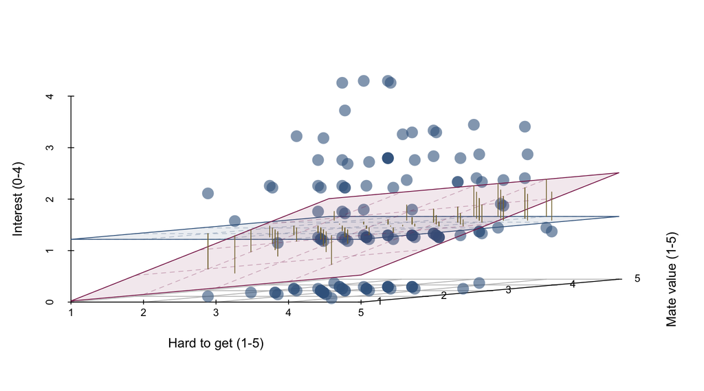

## Slide 52

Video clip: [lazinc durt we are coming](https://profandyfield.github.io/statistics_lectures/ds_03_fit/media/lazinc_durt_we_are_coming.mp4)

## Slide 53: Mean squared error (MS)

> **Note: Statis-tip**

> Why do we use mean squared error?
> - A sum/total of squared errors depends on the amount of information used to compute it. (If you add more squared errors, the sum increases.)
> - We can’t compare sums of squared errors based on different amounts of information
> - We can compute the average or mean squared error by dividing a SS by the amount of information used to compute it
> - The df quantifies the amount of information used to compute a sum of squared errors

$$\text{MS} = \frac{\text{SS}}{\text{df}}$$

## Slide 54: Mean squared error (MS)

- **MS<sub>R</sub>**
  - Average residual/error variability (variability between the model and the observed data)
  - How badly the model fits (on average)

$$\begin{aligned} \text{MS}_\text{R} = \frac{\text{SS}_\text{R}}{\text{df}} = \frac{9.14}{8} = 1.14 \\ \end{aligned}$$

- **MS<sub>M</sub>**
  - Average model variability (difference in variability between the model and the grand mean)
  - How much better the model is at predicting *Y* than the mean
  - How well the model fits (on average)

$$\begin{aligned} \text{MS}_\text{M} = \frac{\text{SS}_\text{M}}{\text{df}} = \frac{13.25}{1} = 13.25 \\ \end{aligned}$$

## Slide 55: Testing the model fit: the F-statistic

- If the model results in better prediction than using the mean, then MS<sub>M</sub> should be greater than MS<sub>R</sub>
- The *F*-statistic is the ratio of MS<sub>M</sub> to MS<sub>R</sub>
  - It’s the good-to-shit ratio

$$\begin{aligned} F = \frac{\text{MS}_\text{M}}{\text{MS}_\text{R}} = \frac{13.25}{1.14} = 11.62 \\ \end{aligned}$$

```r
ite_lm <- lm(belief ~ repetition, data = ite_tib)
ite_aov <- anova(ite_lm)
display(ite_aov)
```

| Parameter | Sum_Squares | df | Mean_Square | F | p |
| --- | --- | --- | --- | --- | --- |
| repetition | 13.26 | 1 | 13.26 | 11.61 | 0.009 |
| Residuals | 9.14 | 8 | 1.14 |  |  |

## Slide 56: Testing the model fit: the F-statistic

$$\text{interest}_i = \hat{b}_0 + \hat{b}_1\text{hard to get}_i + \hat{b}_2\text{mate value}_i +e_i$$

```r
test_wald(more_hard_lm) |>
  display()
```

| Name | Model | df | df_diff | F | p |
| --- | --- | --- | --- | --- | --- |
| Null model | lm | 127 |  |  |  |
| Full model | lm | 125 | 2 | 4.27 | 0.016 |

> **Important: ReportR**

> Overall, including both playing hard to get and mate value significantly improved the fit of the model, *F*(2, 125) = 4.27, *p* = 0.016.

## Slide 57: Testing the model fit: R2

- *R*<sup>2</sup>
  - The proportion of variance accounted for by the model
  - The Pearson correlation between observed and predicted scores squared

$$\begin{aligned} R^2 = \frac{\text{SS}_\text{M}}{\text{SS}_\text{T}} = \frac{13.25}{22.40} = 0.59 \\ \end{aligned}$$

- **Adjusted *R*<sup>2</sup>**
  - *R*<sup>2</sup> increases as you add more predictors (unless those predictors explain zero variance)
  - Adjusted *R*<sup>2</sup> is an estimate of *R*<sup>2</sup> adjusted for the number of parameters in the model.

```r
ite_lm <- lm(belief ~ repetition, data = ite_tib)
ite_fit <- model_performance(ite_lm)
display(ite_fit)
```

| AIC | AICc | BIC | R2 | R2 (adj.) | RMSE | Sigma |
| --- | --- | --- | --- | --- | --- | --- |
| 33.5 | 37.5 | 34.4 | 0.59 | 0.54 | 0.96 | 1.07 |

## Slide 58: Testing the model fit: R2

$$\text{interest}_i = \hat{b}_0 + \hat{b}_1\text{hard to get}_i + \hat{b}_2\text{mate value}_i +e_i$$

```r
model_performance(more_hard_lm) |>
  display()
```

| AIC | AICc | BIC | R2 | R2 (adj.) | RMSE | Sigma |
| --- | --- | --- | --- | --- | --- | --- |
| 390.8 | 391.2 | 402.3 | 0.06 | 0.05 | 1.08 | 1.09 |

> **Important: ReportR**

> Overall, including both playing hard to get and mate value significantly accounted for 6% of the variance in expressions of interest, or 5% adjusting for the number of predictors (*R*<sup>2</sup> = 0.06, *R*<sup>2</sup><sub>adjusted</sub> = 0.05).

## Slide 59: Summary

- Multiple predictors can be added to a linear model
  - *b*s are the change in the outcome associated with a unit change in the predictor **when other predictors are held constant**
  - Other things being equal, predictors are entered based on theory.
- We evaluate fit of a general linear model using Sums of Squared Errors (**SS**)
  - SS<sub>T</sub> = the **total** variance/error in observed scores
  - SS<sub>R</sub> = the **total** variance/error in predicted scores
  - S<sub>M</sub> = the **total** reduction in variance/error due to the model
- It can be useful to convert totals to averages or Mean Squared Errors (**MS**)
  - MS<sub>R</sub> = the **average** variance/error in predicted scores
  - MS<sub>M</sub> = the **average** reduction in variance/error due to the model
- *R*<sup>2</sup> is the proportion of variance in observed scores accounted for by the model
- *F* is the average variance accounted for by the model compared to the model’s error in prediction